# Replication replication

Will Lowe

2018-07-02

## Replicating WEFAT

Here we’ll get some WEFAT analyses going. I haven’t implemented the sample permutation test that’s in the paper yet, so we’ll use the simple bootstrapping technique in `wefat_boot` and make a picture.

First we load up the package

```r
library(cbn)

library(ggplot2)
theme_set(theme_minimal())
```

Then grab the items from the first WEFAT study and the vectors corresponding to those words

```r
its <- cbn_get_items("WEFAT", 1)
its
```

```
#>      Study        Condition          Word
#> 599 WEFAT1          Careers    technician
#> 600 WEFAT1          Careers    accountant
#> 601 WEFAT1          Careers    supervisor
#> 602 WEFAT1          Careers      engineer
#> 603 WEFAT1          Careers        worker
#> 604 WEFAT1          Careers      educator
#> 605 WEFAT1          Careers         clerk
#> 606 WEFAT1          Careers     counselor
#> 607 WEFAT1          Careers     inspector
#> 608 WEFAT1          Careers      mechanic
#> 609 WEFAT1          Careers       manager
#> 610 WEFAT1          Careers     therapist
#> 611 WEFAT1          Careers administrator
#> 612 WEFAT1          Careers   salesperson
```

[output cut: 52 more lines]

```r
its_vecs <- cbn_item_vectors[its$Word, ]
dim(its_vecs)
```

```
#> [1]  66 300
```

Now to run get bootstrapped differences of cosines

```r
res <- wefat_boot(its, its_vecs, x_name = "Careers",
                  a_name = "MaleAttributes", b_name = "FemaleAttributes",
                  se.calc = "quantile")

head(res)
```

```
#>        Careers       diff        lwr         upr     median
#> 1        nurse -0.1766406 -0.2254610 -0.11594432 -0.1733524
#> 2 receptionist -0.1369632 -0.1822573 -0.08849465 -0.1332543
#> 3    hygienist -0.1182356 -0.1480125 -0.07775986 -0.1134647
#> 4    librarian -0.1158335 -0.1403188 -0.08514826 -0.1142018
#> 5 nutritionist -0.1115838 -0.1543883 -0.05746074 -0.1089567
#> 6    therapist -0.1042064 -0.1467539 -0.05069220 -0.1030447
```

This is a bit hard to interpret, so we’ll make a picture

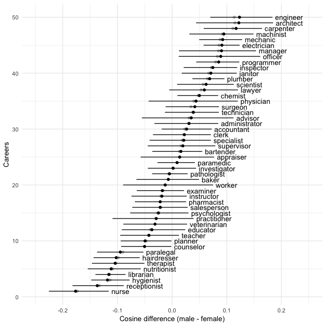

```r
ggplot(res, aes(x = median, y = 1:nrow(res))) +
  geom_point(col = "grey") +
  geom_point(aes(x = diff)) +
  geom_errorbarh(aes(xmin = lwr, xmax = upr), height = 0) +
  geom_text(aes(x = upr, label = Careers), hjust = "left", nudge_x = 0.005) +
  xlim(-0.25, 0.25) +
  ylab("Careers") +
  xlab("Cosine difference (male - female)")
```

This will work quite generally for WEFATs, but remember to mention the right condition name in `geom_text`.

## The Gender of Androgenous Names

First we get the vector differences

```r
its <- cbn_get_items("WEFAT", 2)
its_vecs <- cbn_item_vectors[its$Word, ]
res <- wefat_boot(its, its_vecs, x_name = "AndrogynousNames",
                  a_name = "MaleAttributes", b_name = "FemaleAttributes",
                  se.calc = "quantile")
```

Then we find the gender proportions for each name from the census.  
This is most easily done using the `gender` package, which queries the US Social Security Administration to get the proportion of stated males and females with any particular first name.

This data is bundled with the package, so we’ll join this to `res`

```r
data(cbn_gender_name_stats)
head(cbn_gender_name_stats)
```

```
#>     name proportion_male proportion_female gender year_min year_max
#> 1   Adam          0.9959            0.0041   male     1932     2012
#> 2 Adrian          0.9268            0.0732   male     1932     2012
#> 3  Agnes          0.0023            0.9977 female     1932     2012
#> 4  Aisha          0.0014            0.9986 female     1932     2012
#> 5  Aisha          0.0014            0.9986 female     1932     2012
#> 6   Alan          0.9968            0.0032   male     1932     2012
```

```r
res <- merge(res, cbn_gender_name_stats,
             by.x = "AndrogynousNames", by.y = "name")
```

If you want to do it yourself, e.g. to look at gender over different time periods, or use a different gender source, then

```r
library(gender)

names <- c("Hugh", "Pugh", "Barney")
gender_name_stats <- gender(names)
```

and replace `cbn_gender_name_stats` with `gender_name_stats`.

To see how they relate, we’ll plot proportion male with the `diff` column of `res`

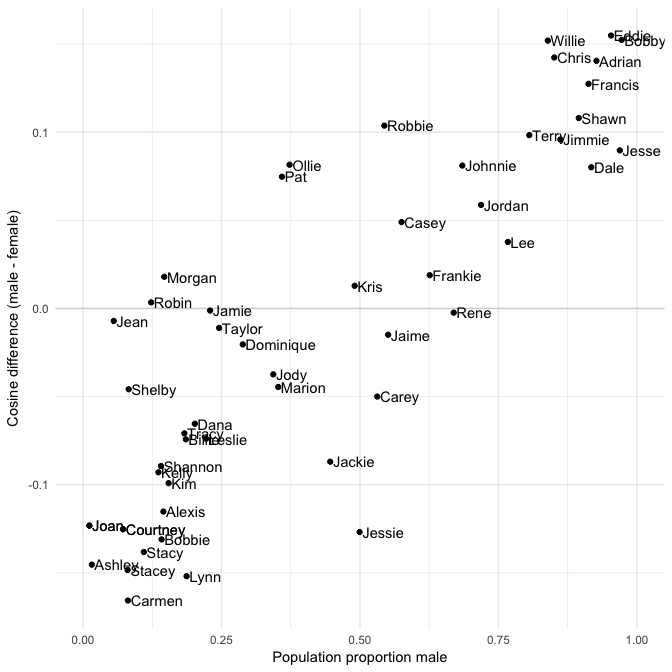

```r
ggplot(res, aes(x = proportion_male, y = diff)) +
  geom_hline(yintercept = 0, alpha = 0.5, color = "grey") +
  geom_point() +
  geom_text(aes(label = AndrogynousNames), hjust = "left", nudge_x = 0.005) +
  xlim(0, 1) +
  xlab("Population proportion male") +
  ylab("Cosine difference (male - female)")
```

The correlation is

```r
cor.test(res$diff,res$proportion_male)
```

```
#>
#>  Pearson's product-moment correlation
#>
#> data:  res$diff and res$proportion_male
#> t = 11.421, df = 50, p-value = 1.526e-15
#> alternative hypothesis: true correlation is not equal to 0
#> 95 percent confidence interval:
#>  0.7517686 0.9116148
#> sample estimates:
#>       cor
#> 0.8502362
```